# 웹크롤링 강의(PDF편)

# step2

### package 설치

#### package = 함수를 담아놓음 묶음, 설치할 때 install.pakages(“패키지명”), 불러올 때 library(패키지명), 오른쪽 아래 창(Packages)에서 설치 여부 확인

```r
#install.packages("tidyverse")
library(tidyverse)
```

#### tidyverse는 데이터를 불러오고, 정리하고, 변형하는 함수가 내장된 패키지. 시각화, 모델링 함수도 적용.

```r
#install.packages("rvest")
library(rvest)
```

#### 웹에 있는 html 문서를 읽어올 때 사용하는 함수 묶음.

## 분석 데이터2 = “리얼미터_지지율_분석(TBS)”, (http://www.realmeter.net/category/pdf/)

#### 무엇을 분석할 것인가 = 정당지지율 일간 집계

# 1. PDF -> HTML

#### 1-1. adobe acrobat DC에서 PDF 파일 열기

#### 1-2. PDF HTML 문서로 내보내기

# 2. R에서 html 문서 읽기

## 2-1. read_html(html 문서 읽어오기), html_table(table 속성만 뽑아내기), list -> data.frame [[번호]]

```r
real_5_1 <- read_html('real_5_1.html')
```

#### *윈도우에서는 인코딩 문제가 있어 Sys.setlocale(“LC_ALL”,“English”), Sys.setlocale(“LC_ALL”,“Korean”)을 붙여줘야 함.

```r
real_5_1  <- real_5_1 %>%
  html_table(fill = T)
real_5_1  <- real_5_1[[6]]
```

#### *read_html(), html_table() 함수는 모두 데이터를 list 형식으로 저장. list는 정해진 규칙없이 데이터를 저장하는 형식.

## 2-2. for 반복문, 데이터 모으기(rbind, cbind)

#### *rbind = 데이터 프레임 아래로 결합(쌓기), 열의 수가 같아야 함. ####* cbind = 데이터 프레임 옆으로 결합(쌓기), 행의 수가 같아야 함.

```r
real_5_daily <- NULL
```

#### *데이터 담을 그릇 만들기

```r
for(i in 1:4){
  a <- read_html(str_c('real_5_', i, '.html')) # str_c
  a <- a %>%
    html_table(fill = T)
  a <- a[[6]]
  real_5_daily <- rbind(real_5_daily, a)
  print(str_c(i, "번째 pdf가 변환됐습니다")) # str_c
}
```

```
## [1] "1번째 pdf가 변환됐습니다"
## [1] "2번째 pdf가 변환됐습니다"
## [1] "3번째 pdf가 변환됐습니다"
## [1] "4번째 pdf가 변환됐습니다"
```

# 3. 데이터 전처리

#### *무엇을 지울 것인가 결정 (“|”)

## 3-1. str_remove_all와 str_remove

```r
real_5_daily$X3 <- real_5_daily$X3 %>%
  str_remove_all("\\|")
real_5_daily$X5 <- real_5_daily$X5 %>%
  str_remove_all("\\|")
```

## 3-2. 반복문의 반목문, nrow, ncol

```r
for(i in 1:nrow(real_5_daily)){
  for(t in 1:ncol(real_5_daily)){
    real_5_daily[i, t] <- real_5_daily[i, t] %>%
      str_remove_all("\\|")
  }
}
```

#### *nrow(데이터명) = 데이터프레임의 행의 갯수, ncol(데이터명) = 데이터 프레임의 열의 갯수

## 3-3. 중복행 제거 unique

```r
real_5_daily <- unique(real_5_daily)
```

## 3-4. 비어있는 열 제거 select

```r
real_5_daily <- real_5_daily %>%
  select(-1, -3, -5, -7, -9, -11, -13, -15, -17, -19, -22)
```

## 3-5. 칼럼 이름 정하기 colnames

```r
colnames(real_5_daily) <- c("날짜", "민주당", "자유한국당", "바른미래당", "민주평화당", "정의당", "기타정당", "없음", "모름무응답", "무당층", "계")
glimpse(real_5_daily)
```

```
## Observations: 21
## Variables: 11
## $ 날짜       <chr> "04/22(월)", "04/23(화)", "04/24(수)", "04/25(목)", "04/26…
## $ 민주당     <chr> "38.4", "38.8", "38.8", "37.8", "37", "38.1", "39.9", "…
## $ 자유한국당 <chr> "32.1", "32.8", "31.5", "29.3", "30.5", "32.7", "34.1", "…
## $ 바른미래당 <chr> "4.2", "5.2", "5.1", "5.4", "6", "5.8", "5.7", "4.8", "4.…
## $ 민주평화당 <chr> "2", "2.7", "3.6", "2.8", "2.4", "2.1", "1.3", "1.7", "3.…
## $ 정의당     <chr> "7.7", "7.8", "7.5", "7.7", "8.6", "7.1", "5.5", "5.8",…
## $ 기타정당   <chr> "1.3", "0.8", "1.5", "2.4", "1.8", "1.5", "1.7", "1.3", …
## $ 없음       <chr> "12.3", "10.3", "11", "12.9", "11.8", "10.7", "9.2", "…
## $ 모름무응답 <chr> "2", "1.6", "1", "1.7", "1.9", "2", "2.6", "2.4", "1.9", …
## $ 무당층     <chr> "14.3", "11.9", "12", "14.6", "13.7", "12.7", "11.8", "…
## $ 계         <chr> " 100.0", " 100.0", " 100.0", " 100.0", " 100.0", " 1…
```

## 3-6. character(문자형 벡터) -> numeric(숫자형 벡터), as.numeric

#### *gather(하나의 열(벡털)로 데이터 모으기)

```r
real_5_daily <- real_5_daily %>%
  gather(정당, 지지율, 2:11)

real_5_daily$지지율 <- as.numeric(real_5_daily$지지율)
```

# 4. 데이터 분석하기

## 4-1. 필터링 filter(걸러내는)

```r
real_5_daily <- real_5_daily %>%
  filter(정당 != "계")

real_5_daily1 <- real_5_daily %>%
  filter(정당 == "민주당" | 정당 == "자유한국당")

real_5_daily1 <- real_5_daily1 %>%
  spread(정당, 지지율)
```

```r
real_5_daily1 <- real_5_daily1 %>%
  mutate(격차 = 민주당 - 자유한국당)

real_5_daily1 <- real_5_daily1 %>%
  gather(정당, 지지율, 2:4)
```

## 4-2. 시각화

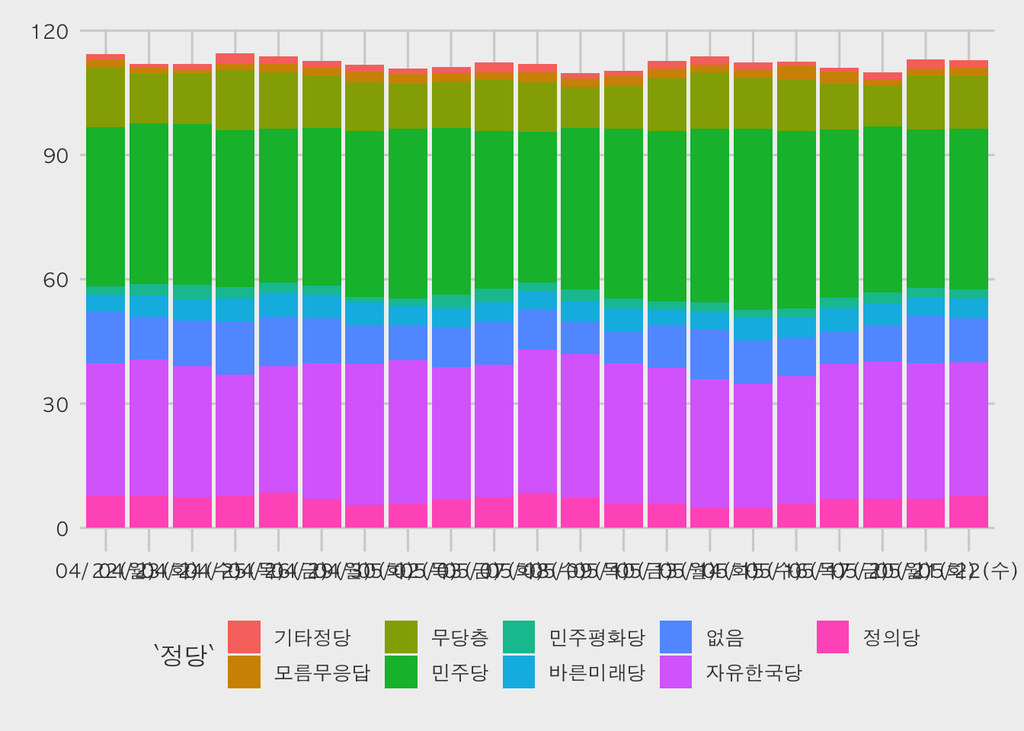

```r
library(ggthemes)

ggplot(real_5_daily, aes(x = 날짜, y = 지지율, fill = 정당)) +
  geom_bar(stat = "identity") +
  theme_fivethirtyeight(base_family = "AppleGothic")
```

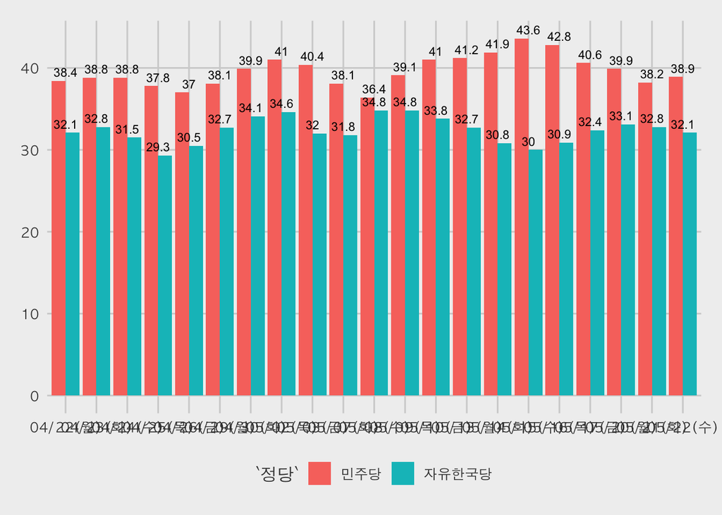

```r
ggplot(real_5_daily1 %>%
         filter(정당 != "격차"), aes(x = 날짜, y = 지지율, fill = 정당)) +
  geom_bar(stat = "identity", position = "dodge") +
  geom_text(aes(label = 지지율), size = 3, vjust = -0.5) +
  theme_fivethirtyeight(base_family = "AppleGothic")
```

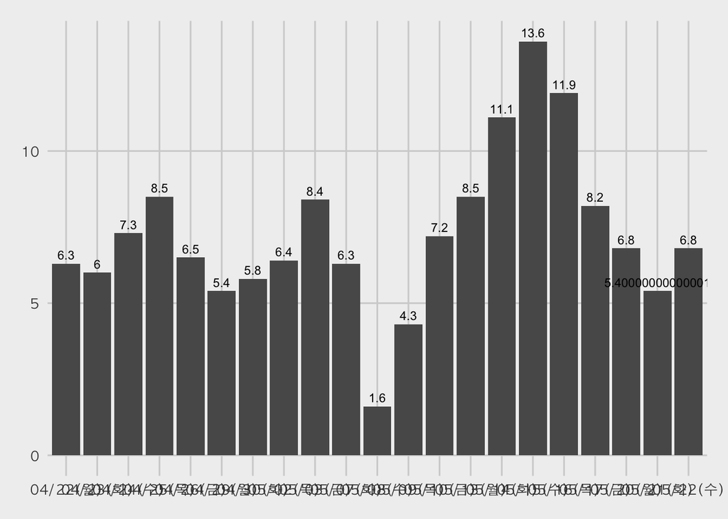

```r
ggplot(real_5_daily1 %>%
         filter(정당 == "격차"), aes(x = 날짜, y = 지지율)) +
  geom_bar(stat = "identity", position = "dodge") +
  geom_text(aes(label = 지지율), size = 3, vjust = -0.5) +
  theme_fivethirtyeight(base_family = "AppleGothic")
```

## 4-3. 의미 분석

#### 정당별 지지율 분석

#### 날짜별 민주당과 자유한국당의 지지율 차이, 5월 8일, 5월 15일 등 특이값 분석